# Week 2 Exercise

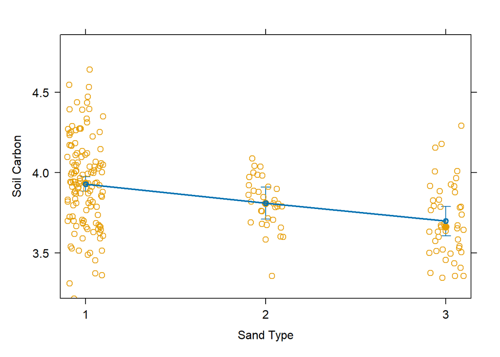

```r
plot(eff_sand,
     main = "",
     ylab = "Soil Carbon",
     xlab = "Sand Type",
     transformation = list(link = log, inverse = exp))
```

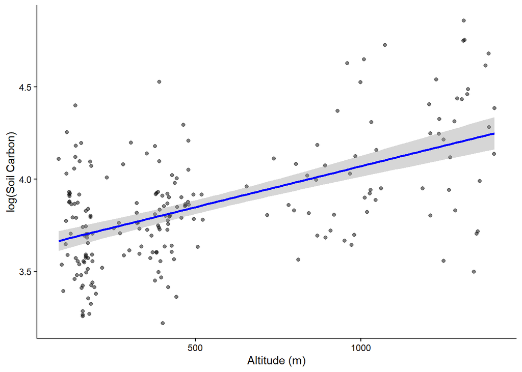

```r
ggplot(data, aes(x = altitude, y = log.soil.carbon)) +
  geom_point(alpha = 0.5) +
  geom_smooth(method = "lm", color = "blue") +
  ylab("log(Soil Carbon)") +
  xlab("Altitude (m)") +
  theme_classic()
```

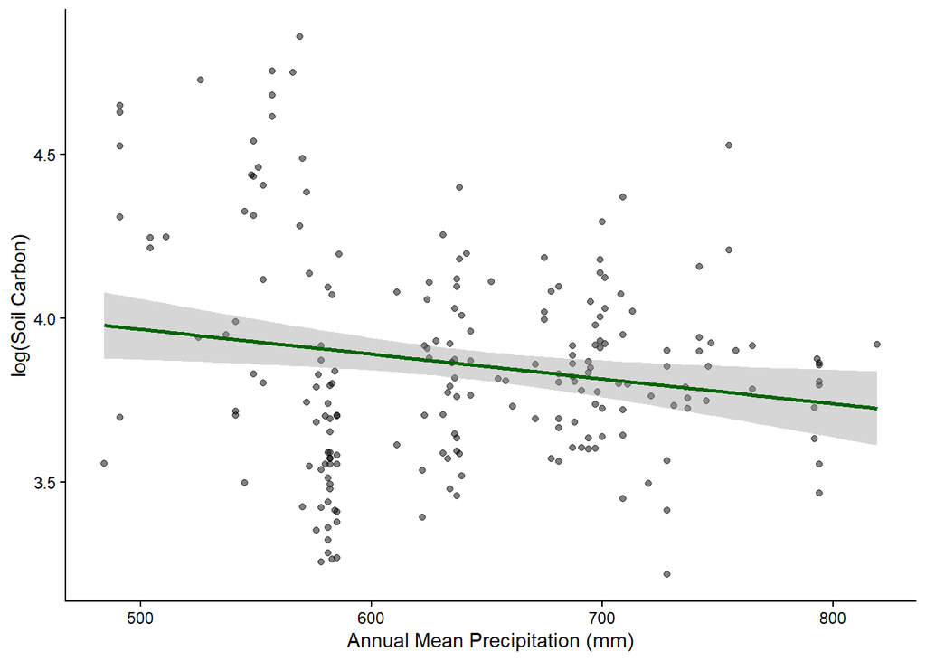

```r
ggplot(data, aes(x = annual.mean.precipitation, y = log.soil.carbon)) +
  geom_point(alpha = 0.5) +
  geom_smooth(method = "lm", color = "darkgreen") +
  ylab("log(Soil Carbon)") +
  xlab("Annual Mean Precipitation (mm)") +
  theme_classic()
```

use effect

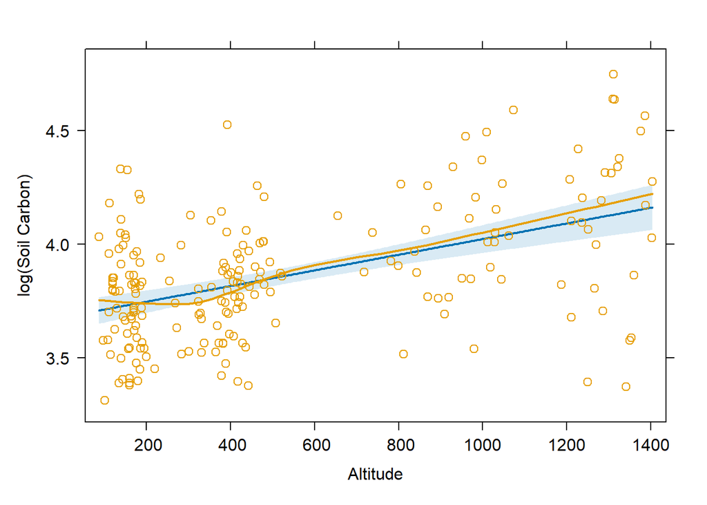

```r
eff_alt <- effect("altitude", m_base, partial.residuals = TRUE)
plot(eff_alt,
     main = "",
     ylab = "log(Soil Carbon)",
     xlab = "Altitude")
```

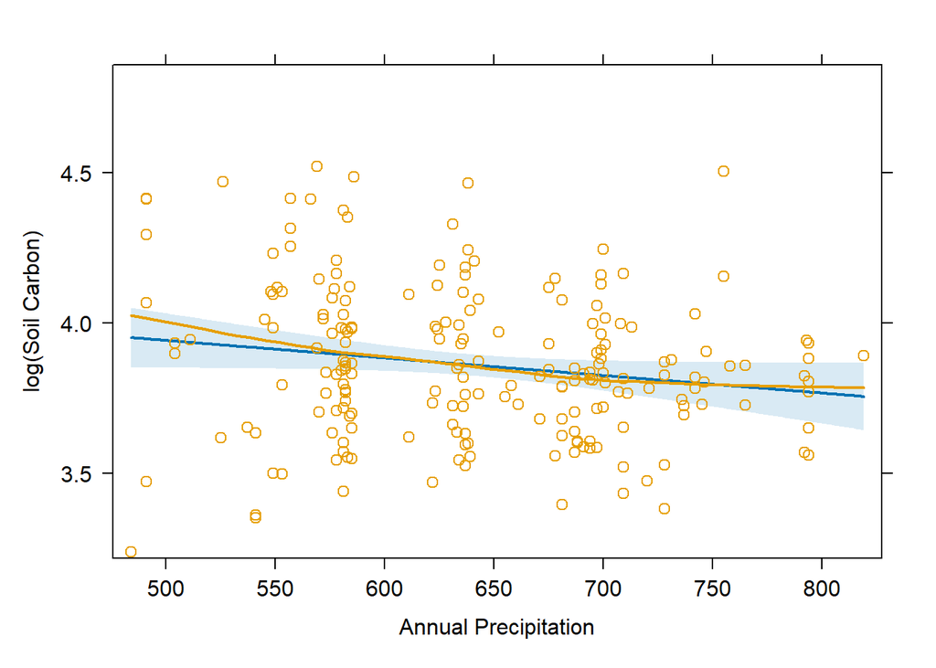

```r
eff_precip <- effect("annual.mean.precipitation", m_base, partial.residuals = TRUE)
plot(eff_precip,
     main = "",
     ylab = "log(Soil Carbon)",
     xlab = "Annual Precipitation")
```

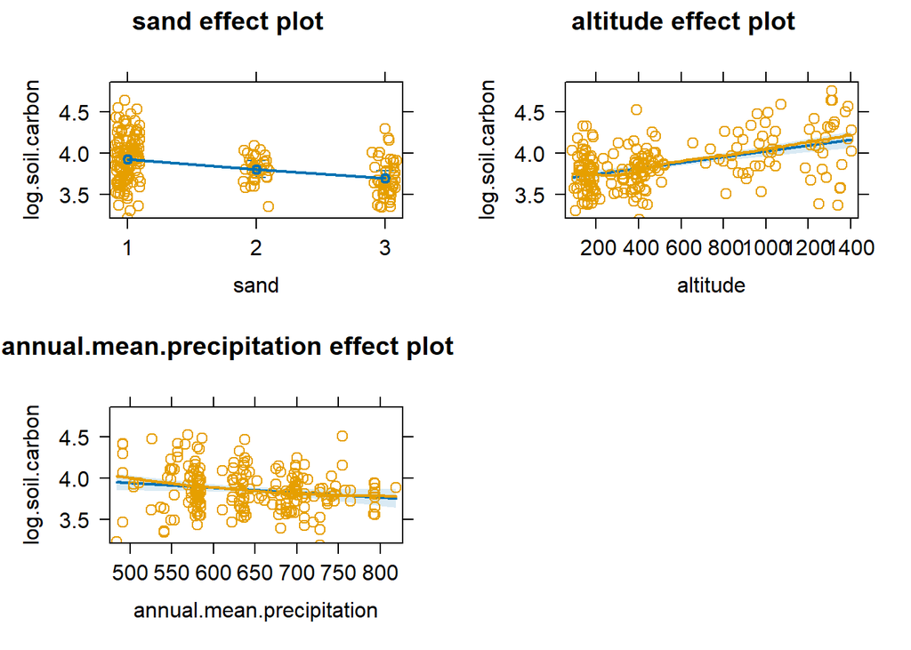

```r
eff_all <- allEffects(m_base, partial.residuals = TRUE)
plot(eff_all)
```

```r
library(emmeans)
anova_sand <- lm(log.soil.carbon ~ sand, data = data)
emmeans(anova_sand, pairwise ~ sand, adjust = "Tukey")
```

```
## $emmeans
##  sand emmean     SE  df lower.CL upper.CL
##  1      3.95 0.0262 205     3.90     4.00
##  2      3.82 0.0520 205     3.71     3.92
##  3      3.63 0.0445 205     3.54     3.71
##
## Confidence level used: 0.95
##
## $contrasts
##  contrast      estimate     SE  df t.ratio p.value
##  sand1 - sand2    0.134 0.0582 205   2.311  0.0565
##  sand1 - sand3    0.326 0.0516 205   6.305 <0.0001
##  sand2 - sand3    0.191 0.0684 205   2.793  0.0157
##
## P value adjustment: tukey method for comparing a family of 3 estimates
```

```r
emm_res <- emmeans(anova_sand, pairwise ~ sand, adjust = "Tukey")
```

Based on the model-adjusted estimated means (emmeans), sand type had a clear effect on soil carbon stock. Soil carbon in sand3 was significantly lower than in sand1 and sand2 (sand1–sand3: p < 0.0001, sand2–sand3: p = 0.016), while the difference between sand1 and sand2 was marginally significant (p = 0.056). Overall, this suggests that sand type has a notable influence on soil carbon.

So far, the factors that had significant effects on soil carbon as single predictors were sand, altitude, and annual mean precipitation. Other factors did not show significant effects on soil carbon on their own.

For interaction effects, the following combinations will be examined:

sand × species richness

sand × precipitation

altitude × temperature

altitude × precipitation

precipitation × target species richness

intaraction between sand and target.species.richness

```r
m_sand_rich <- lm(log.soil.carbon ~ sand*target.species.richness, data = data)
summary(m_sand_rich)
```

```
##
## Call:
## lm(formula = log.soil.carbon ~ sand * target.species.richness,
##     data = data)
##
## Residuals:
##      Min       1Q   Median       3Q      Max
## -0.73604 -0.19300 -0.04076  0.15221  0.90524
##
## Coefficients: (1 not defined because of singularities)
##                                 Estimate Std. Error t value Pr(>|t|)
## (Intercept)                     3.952791   0.050833  77.760   <2e-16 ***
## sand2                          -0.179965   0.119214  -1.510   0.1328
## sand3                          -0.311379   0.125989  -2.471   0.0143 *
## target.species.richness2        0.007854   0.065386   0.120   0.9045
## target.species.richness3       -0.020968   0.078498  -0.267   0.7897
## target.species.richness4       -0.004080   0.101666  -0.040   0.9680
## target.species.richness5       -0.092824   0.309206  -0.300   0.7643
## sand2:target.species.richness2  0.001118   0.165926   0.007   0.9946
## sand3:target.species.richness2 -0.040620   0.157227  -0.258   0.7964
## sand2:target.species.richness3  0.106281   0.159819   0.665   0.5068
## sand3:target.species.richness3 -0.064336   0.163116  -0.394   0.6937
## sand2:target.species.richness4  0.072320   0.201418   0.359   0.7199
## sand3:target.species.richness4  0.067345   0.181460   0.371   0.7109
## sand2:target.species.richness5        NA         NA      NA       NA
## sand3:target.species.richness5  0.181242   0.394221   0.460   0.6462
## ---
## Signif. codes:  0 '***' 0.001 '**' 0.01 '*' 0.05 '.' 0.1 ' ' 1
##
## Residual standard error: 0.305 on 194 degrees of freedom
## Multiple R-squared:  0.1754, Adjusted R-squared:  0.1201
## F-statistic: 3.174 on 13 and 194 DF,  p-value: 0.0002447
```

```r
sum_sand_rich <- summary(m_sand_rich)
```

There was no interaction between sand and target species richness.

sand and annual.mean.precipitation

```r
m_sand_precip <- lm(log.soil.carbon ~ sand*annual.mean.precipitation, data = data)
summary(m_sand_precip)
```

```
##
## Call:
## lm(formula = log.soil.carbon ~ sand * annual.mean.precipitation,
##     data = data)
##
## Residuals:
##      Min       1Q   Median       3Q      Max
## -0.69972 -0.18599 -0.00584  0.17877  0.79097
##
## Coefficients:
##                                   Estimate Std. Error t value Pr(>|t|)
## (Intercept)                      5.1818742  0.2004037  25.857  < 2e-16 ***
## sand2                           -1.7561640  0.6116250  -2.871  0.00452 **
## sand3                           -2.7051760  0.8641267  -3.131  0.00200 **
## annual.mean.precipitation       -0.0019153  0.0003095  -6.188 3.34e-09 ***
## sand2:annual.mean.precipitation  0.0024713  0.0008761   2.821  0.00527 **
## sand3:annual.mean.precipitation  0.0038644  0.0014579   2.651  0.00867 **
## ---
## Signif. codes:  0 '***' 0.001 '**' 0.01 '*' 0.05 '.' 0.1 ' ' 1
##
## Residual standard error: 0.2744 on 202 degrees of freedom
## Multiple R-squared:  0.3049, Adjusted R-squared:  0.2877
## F-statistic: 17.72 on 5 and 202 DF,  p-value: 1.506e-14
```

```r
sum_sand_precip <- summary(m_sand_precip)
```

The effect of precipitation reduces the differences in soil carbon among the sand types.

altitude and temperature

```r
m_alt_temp <- lm(log.soil.carbon ~ altitude*annual.mean.temperature, data = data)
summary(m_alt_temp)
```

```
##
## Call:
## lm(formula = log.soil.carbon ~ altitude * annual.mean.temperature,
##     data = data)
##
## Residuals:
##      Min       1Q   Median       3Q      Max
## -0.79315 -0.16210  0.00671  0.14768  0.75059
##
## Coefficients:
##                                    Estimate Std. Error t value Pr(>|t|)
## (Intercept)                       3.884e+00  7.129e-02  54.484  < 2e-16 ***
## altitude                         -1.394e-04  1.653e-04  -0.843 0.400117
## annual.mean.temperature          -3.706e-02  9.387e-03  -3.948 0.000108 ***
## altitude:annual.mean.temperature  7.516e-05  1.978e-05   3.800 0.000191 ***
## ---
## Signif. codes:  0 '***' 0.001 '**' 0.01 '*' 0.05 '.' 0.1 ' ' 1
##
## Residual standard error: 0.2617 on 204 degrees of freedom
## Multiple R-squared:  0.3617, Adjusted R-squared:  0.3523
## F-statistic: 38.53 on 3 and 204 DF,  p-value: < 2.2e-16
```

```r
sum_alt_temp <- summary(m_alt_temp)
```

Altitude mitigates the decrease in soil carbon caused by higher temperatures.

altitude and annual.mean,precipitation

```r
m_alt_precip <- lm(log.soil.carbon ~ altitude*annual.mean.precipitation, data = data)
summary(m_alt_precip)
```

```
##
## Call:
## lm(formula = log.soil.carbon ~ altitude * annual.mean.precipitation,
##     data = data)
##
## Residuals:
##      Min       1Q   Median       3Q      Max
## -0.78171 -0.17306 -0.00515  0.16458  0.69236
##
## Coefficients:
##                                      Estimate Std. Error t value Pr(>|t|)
## (Intercept)                         2.931e+00  3.573e-01   8.201 2.63e-14 ***
## altitude                            1.729e-03  4.832e-04   3.577 0.000433 ***
## annual.mean.precipitation           1.159e-03  5.738e-04   2.019 0.044752 *
## altitude:annual.mean.precipitation -2.192e-06  8.141e-07  -2.692 0.007693 **
## ---
## Signif. codes:  0 '***' 0.001 '**' 0.01 '*' 0.05 '.' 0.1 ' ' 1
##
## Residual standard error: 0.267 on 204 degrees of freedom
## Multiple R-squared:  0.3355, Adjusted R-squared:  0.3257
## F-statistic: 34.33 on 3 and 204 DF,  p-value: < 2.2e-16
```

```r
sum_alt_precip <- summary(m_alt_precip)
```

Altitude has a negative effect on the impact of precipitation on soil carbon.

```r
m_precip_rich <- lm(log.soil.carbon ~ annual.mean.precipitation*target.species.richness, data = data)
summary(m_precip_rich)
```

```
##
## Call:
## lm(formula = log.soil.carbon ~ annual.mean.precipitation * target.species.richness,
##     data = data)
##
## Residuals:
##      Min       1Q   Median       3Q      Max
## -0.71008 -0.22796 -0.01333  0.17805  0.93408
##
## Coefficients:
##                                                      Estimate Std. Error
## (Intercept)                                         4.9752317  0.3851254
## annual.mean.precipitation                          -0.0017190  0.0006013
## target.species.richness2                           -0.5990854  0.4961188
## target.species.richness3                           -1.1515858  0.5584995
## target.species.richness4                           -1.0471981  0.6545668
## target.species.richness5                           -1.9046834  2.3105628
## annual.mean.precipitation:target.species.richness2  0.0009378  0.0007760
## annual.mean.precipitation:target.species.richness3  0.0017115  0.0008578
## annual.mean.precipitation:target.species.richness4  0.0015795  0.0010150
## annual.mean.precipitation:target.species.richness5  0.0028603  0.0037368
##                                                    t value Pr(>|t|)
## (Intercept)                                         12.918  < 2e-16 ***
## annual.mean.precipitation                           -2.859  0.00471 **
## target.species.richness2                            -1.208  0.22866
## target.species.richness3                            -2.062  0.04052 *
## target.species.richness4                            -1.600  0.11123
## target.species.richness5                            -0.824  0.41074
## annual.mean.precipitation:target.species.richness2   1.208  0.22830
## annual.mean.precipitation:target.species.richness3   1.995  0.04740 *
## annual.mean.precipitation:target.species.richness4   1.556  0.12127
## annual.mean.precipitation:target.species.richness5   0.765  0.44492
## ---
## Signif. codes:  0 '***' 0.001 '**' 0.01 '*' 0.05 '.' 0.1 ' ' 1
##
## Residual standard error: 0.3224 on 198 degrees of freedom
## Multiple R-squared:  0.05975,    Adjusted R-squared:  0.01701
## F-statistic: 1.398 on 9 and 198 DF,  p-value: 0.1911
```

```r
sum_precip_rich <- summary(m_precip_rich)
```

In summary, the observed interactions among factors are as follows:

The effect of precipitation reduces the differences in soil carbon among sand types.

Altitude mitigates the decrease in soil carbon caused by higher temperatures.

Altitude has a negative effect on the impact of precipitation on soil carbon.

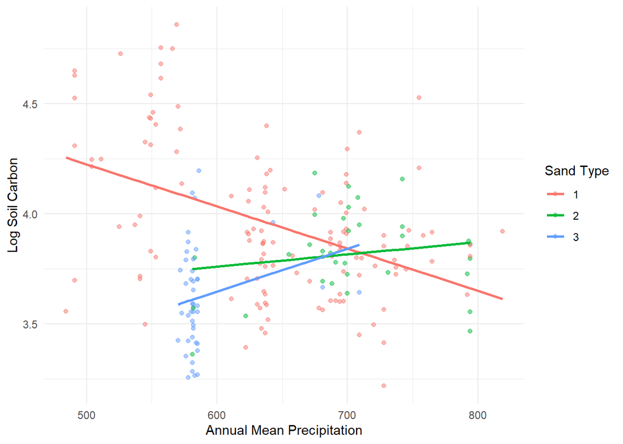

```r
library(ggplot2)


data$pred <- predict(m_sand_precip, newdata = data)


ggplot(data, aes(x = annual.mean.precipitation, y = log.soil.carbon, color = sand)) +
  geom_point(alpha = 0.5) +
  geom_line(aes(y = pred), size = 1) +
  labs(x = "Annual Mean Precipitation", y = "Log Soil Carbon", color = "Sand Type") +
  theme_minimal()
```

The annual mean precipitation shows an interesting effect in its interaction with sand type on soil carbon. Sand type had a significant impact on soil carbon (sand2: -1.76, p = 0.0045; sand3: -2.71, p = 0.0020). Additionally, precipitation reduced soil carbon in the reference sand, but this negative effect was mitigated in sand2 and sand3 due to the interaction with sand type. The overall model was significant (F = 17.72, p < 0.001) and explained approximately 30% of the variation in soil carbon (R² = 0.305). However, soil carbon may also be influenced by country, litter layer, root biomass, and microbial biomass. Therefore, these factors should be incorporated as random effect(country) or interaction terms, and the changes in fixed effects, as well as factors that were not significant on their own, should be re-evaluated.

random effect; country

```r
library(lme4)

m_mixed_country <- lmer(
  log.soil.carbon ~ sand + altitude + annual.mean.precipitation +
    (1 | country),
  data = data
)
```

sand/ randome effect country plot and result

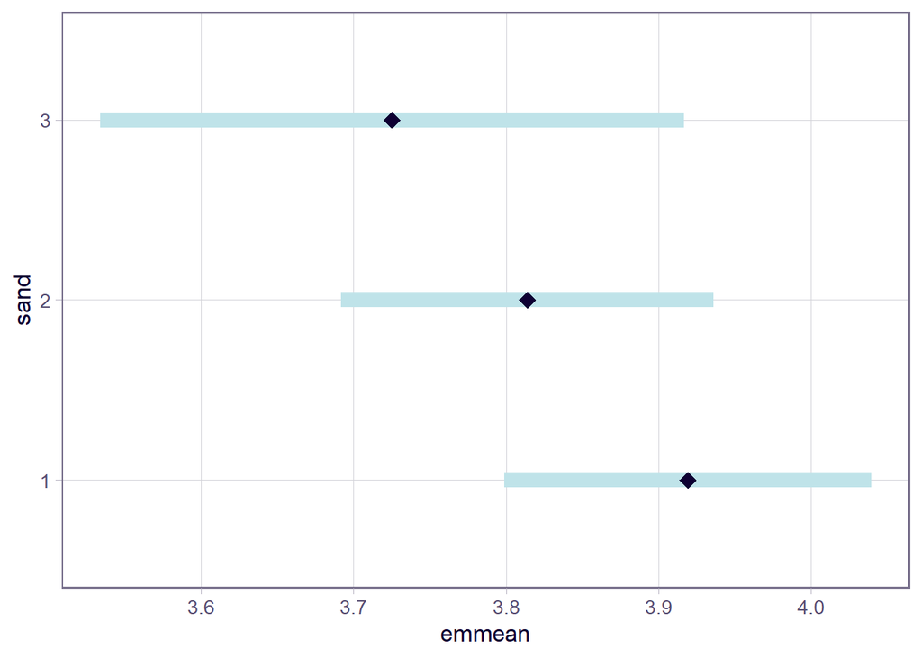

```r
library(emmeans)

emm_sand <- emmeans(m_mixed_country, ~ sand)

plot(emm_sand)
```

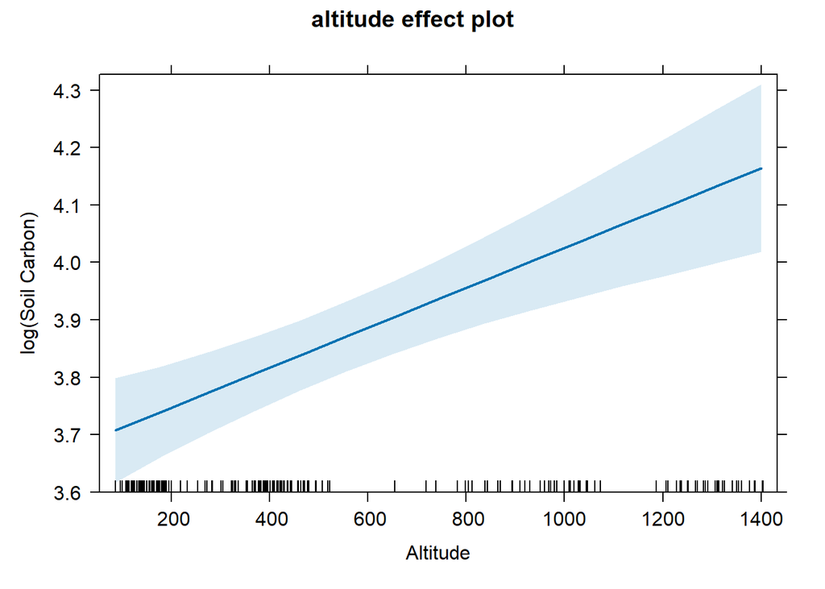

```r
eff_alt <- effect("altitude", m_mixed_country)
plot(eff_alt,
     xlab = "Altitude",
     ylab = "log(Soil Carbon)")
```

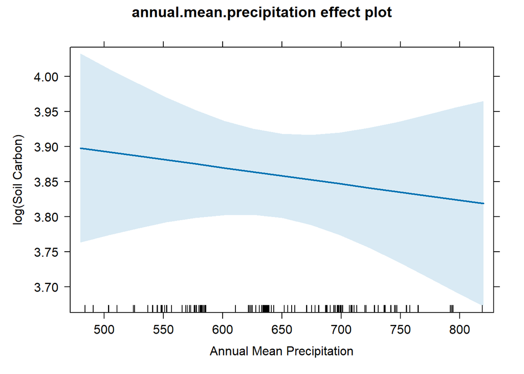

```r
eff_precip <- effect("annual.mean.precipitation", m_mixed_country)
plot(eff_precip,
     xlab = "Annual Mean Precipitation",
     ylab = "log(Soil Carbon)")
```

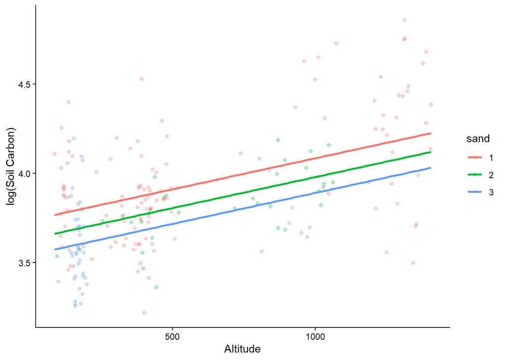

```r
newdat <- expand.grid(
  sand = levels(data$sand),
  altitude = seq(min(data$altitude), max(data$altitude), length = 100),
  annual.mean.precipitation = mean(data$annual.mean.precipitation),
  country = NA
)

newdat$pred <- predict(m_mixed_country, newdata = newdat, re.form = NA)

newdat <- expand.grid(
  sand = levels(data$sand),
  altitude = seq(min(data$altitude), max(data$altitude), length = 100),
  annual.mean.precipitation = mean(data$annual.mean.precipitation),
  country = NA
)

newdat$pred <- predict(m_mixed_country, newdata = newdat, re.form = NA)

ggplot(data, aes(x = altitude, y = log.soil.carbon, color = sand)) +
  geom_point(alpha = 0.3) +
  geom_line(data = newdat,
            aes(x = altitude, y = pred, color = sand),
            size = 1) +
  labs(y = "log(Soil Carbon)",
       x = "Altitude") +
  theme_classic()
```

```r
summary(m_mixed_country)
```

```
## Linear mixed model fit by REML ['lmerMod']
## Formula: log.soil.carbon ~ sand + altitude + annual.mean.precipitation +
##     (1 | country)
##    Data: data
##
## REML criterion at convergence: 68.8
##
## Scaled residuals:
##      Min       1Q   Median       3Q      Max
## -3.01417 -0.70447 -0.00852  0.59237  2.71849
##
## Random effects:
##  Groups   Name        Variance Std.Dev.
##  country  (Intercept) 0.003587 0.05989
##  Residual             0.065644 0.25621
## Number of obs: 208, groups:  country, 6
##
## Fixed effects:
##                             Estimate Std. Error t value
## (Intercept)                3.885e+00  2.624e-01  14.806
## sand2                     -1.054e-01  5.886e-02  -1.790
## sand3                     -1.940e-01  7.607e-02  -2.551
## altitude                   3.478e-04  7.768e-05   4.477
## annual.mean.precipitation -2.332e-04  3.802e-04  -0.613
##
## Correlation of Fixed Effects:
##             (Intr) sand2  sand3  altitd
## sand2        0.141
## sand3       -0.367  0.205
## altitude    -0.396 -0.068  0.333
## annl.mn.prc -0.976 -0.193  0.268  0.237
```

```r
sum_mixed_country <- summary(m_mixed_country)
```

After accounting for between-country variability, sand type and altitude remained significant predictors of soil carbon, whereas the effect of annual mean precipitation was no longer significant.

intaraction of sand and precipitation with counrty effect

```r
m_mixed_country_sd.pre <- lmer(log.soil.carbon ~ sand * annual.mean.precipitation + altitude +
       (1 | country), data = data)

newdat <- expand.grid(
  sand = levels(data$sand),
  annual.mean.precipitation =
    seq(min(data$annual.mean.precipitation),
        max(data$annual.mean.precipitation),
        length = 100),
  altitude = mean(data$altitude),
  country = NA
)

newdat$pred <- predict(
  m_mixed_country_sd.pre,
  newdata = newdat,
  re.form = NA
)
```

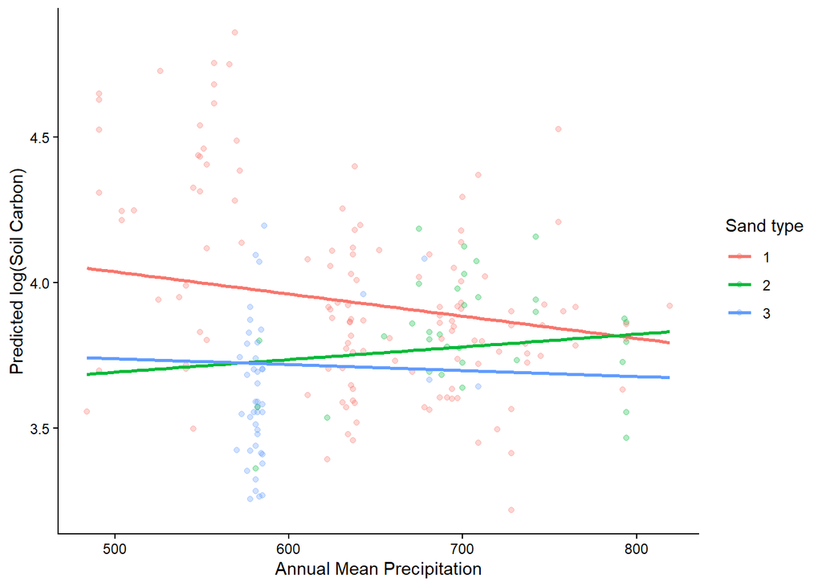

```r
ggplot(data,
       aes(x = annual.mean.precipitation,
           y = log.soil.carbon,
           color = sand)) +
  geom_point(alpha = 0.3) +
  geom_line(data = newdat,
            aes(y = pred),
            size = 1) +
  labs(
    x = "Annual Mean Precipitation",
    y = "Predicted log(Soil Carbon)",
    color = "Sand type"
  ) +
  theme_classic()
```

```r
summary(m_mixed_country_sd.pre)
```

```
## Linear mixed model fit by REML ['lmerMod']
## Formula: log.soil.carbon ~ sand * annual.mean.precipitation + altitude +
##     (1 | country)
##    Data: data
##
## REML criterion at convergence: 90.5
##
## Scaled residuals:
##      Min       1Q   Median       3Q      Max
## -2.98762 -0.67446 -0.02802  0.64070  2.83214
##
## Random effects:
##  Groups   Name        Variance  Std.Dev.
##  country  (Intercept) 0.0004525 0.02127
##  Residual             0.0664387 0.25776
## Number of obs: 208, groups:  country, 6
##
## Fixed effects:
##                                   Estimate Std. Error t value
## (Intercept)                      4.249e+00  2.648e-01  16.047
## sand2                           -9.441e-01  6.000e-01  -1.573
## sand3                           -5.775e-01  9.207e-01  -0.627
## annual.mean.precipitation       -7.624e-04  3.741e-04  -2.038
## altitude                         3.196e-04  6.424e-05   4.975
## sand2:annual.mean.precipitation  1.198e-03  8.644e-04   1.386
## sand3:annual.mean.precipitation  5.582e-04  1.526e-03   0.366
##
## Correlation of Fixed Effects:
##             (Intr) sand2  sand3  annl.. altitd sn2:..
## sand2       -0.414
## sand3       -0.439  0.182
## annl.mn.prc -0.988  0.410  0.411
## altitude    -0.638  0.252  0.424  0.542
## snd2:nnl.m.  0.441 -0.996 -0.197 -0.441 -0.272
## snd3:nnl.m.  0.407 -0.168 -0.998 -0.384 -0.396  0.183
```

```r
sum_mixed_country_sd.pre <- summary(m_mixed_country_sd.pre)
```

The effect of precipitation on soil carbon tended to differ among sand types, but this interaction became weaker after accounting for between-country variability.

## Question 6

Test the hypothesis that microbial biomass depends on species richness, altitude, sand cover, annual mean temperature and precipitation.

I propose to use multi linear regression model, with several confounding variables

```r
microbe<- fundiv[,c("target.species.richness",
                 "altitude",
                 "sand",
                 "annual.mean.temperature",
                 "annual.mean.precipitation",
                 # confounding variables
                 "prop.conifers",
                 "soil.CN.ratio",
                 "litter.decomposition",
                 "wood.decomposition" ,
                 # random variable
                 "species.composition",
                 # The responding variable
                 "microbial.biomass"
                 )]
str(microbe)
```

```
## 'data.frame':    208 obs. of  11 variables:
##  $ target.species.richness  : int  2 2 2 2 2 1 1 1 1 1 ...
##  $ altitude                 : num  87 138 139 138 114 112 120 120 119 134 ...
##  $ sand                     : int  1 1 1 1 1 1 1 1 1 1 ...
##  $ annual.mean.temperature  : num  2.6 2.4 2.4 2.5 2.6 2.5 2.3 2.3 2.2 2.1 ...
##  $ annual.mean.precipitation: int  625 638 638 637 631 631 625 624 623 624 ...
##  $ prop.conifers            : num  0.987 0.257 0.165 0.633 0.721 ...
##  $ soil.CN.ratio            : num  21.5 22 20.3 21.3 27.3 ...
##  $ litter.decomposition     : num  0.536 0.591 0.545 0.859 0.673 ...
##  $ wood.decomposition       : num  0.698 0.576 0.498 0.674 0.395 ...
##  $ species.composition      : chr  "Piab.Pisy" "Be.Piab" "Be.Piab" "Be.Piab" ...
##  $ microbial.biomass        : num  136 351 570 442 517 ...
```

```r
microbe$sand <- as.factor(microbe$sand)
microbe$species.composition <- as.factor(microbe$species.composition)
microbe$target.species.richness <- as.factor(microbe$target.species.richness)
```

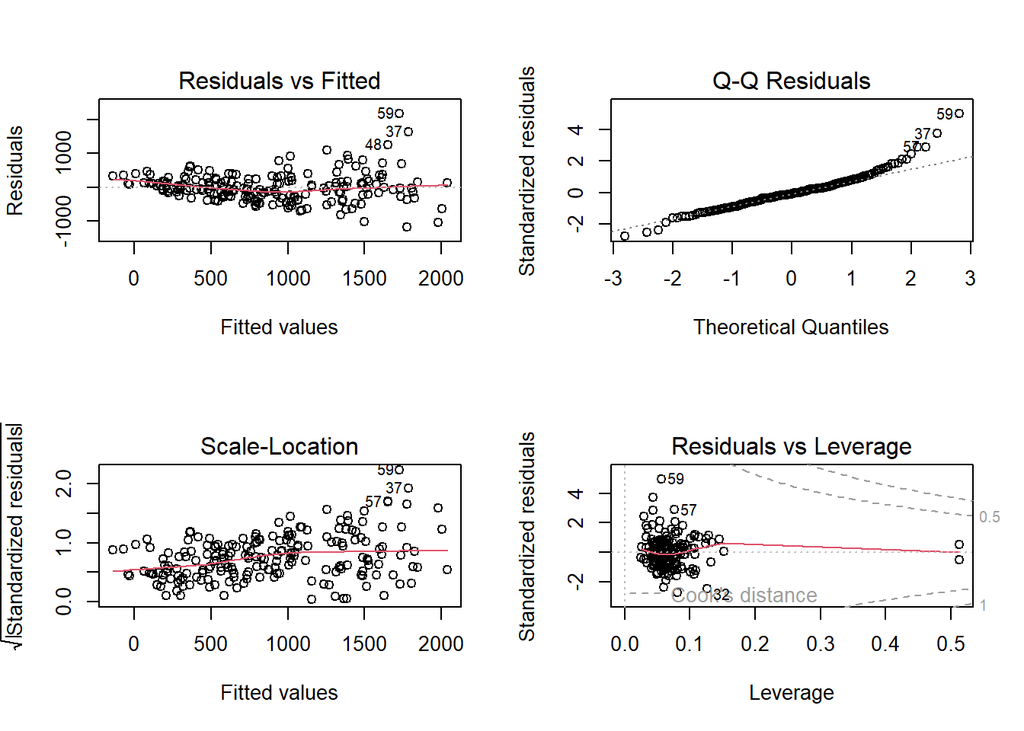

```r
biomass.microbe <- lm(microbial.biomass ~
                          target.species.richness +
                          altitude +
                          sand +
                          annual.mean.temperature +
                          annual.mean.precipitation +
                          prop.conifers +
                          soil.CN.ratio +
                          litter.decomposition +
                          wood.decomposition,
                        data = microbe
                          )
# diagnostic plots
par(mfrow = c(2, 2))
plot(biomass.microbe)
```

```r
par(mfrow = c(1, 1))
# vif
vif(biomass.microbe)
```

```
##                               GVIF Df GVIF^(1/(2*Df))
## target.species.richness   1.191898  4        1.022186
## altitude                  2.401958  1        1.549825
## sand                      2.301722  2        1.231723
## annual.mean.temperature   1.809089  1        1.345024
## annual.mean.precipitation 2.137093  1        1.461880
## prop.conifers             2.153799  1        1.467583
## soil.CN.ratio             1.836403  1        1.355140
## litter.decomposition      1.866325  1        1.366135
## wood.decomposition        1.320870  1        1.149291
```

```r
summary(biomass.microbe)
```

```
##
## Call:
## lm(formula = microbial.biomass ~ target.species.richness + altitude +
##     sand + annual.mean.temperature + annual.mean.precipitation +
##     prop.conifers + soil.CN.ratio + litter.decomposition + wood.decomposition,
##     data = microbe)
##
## Residuals:
##      Min       1Q   Median       3Q      Max
## -1181.55  -262.31   -35.64   180.07  2168.31
##
## Coefficients:
##                            Estimate Std. Error t value Pr(>|t|)
## (Intercept)                592.2003   537.9486   1.101  0.27238
## target.species.richness2   107.0559    84.2434   1.271  0.20539
## target.species.richness3   257.8380    94.3087   2.734  0.00686 **
## target.species.richness4    36.3792   113.4644   0.321  0.74886
## target.species.richness5   -44.6141   327.0237  -0.136  0.89163
## altitude                     0.6720     0.1207   5.567 8.94e-08 ***
## sand2                     -473.8543   101.4608  -4.670 5.75e-06 ***
## sand3                     -784.3555   104.6450  -7.495 2.61e-12 ***
## annual.mean.temperature      3.8863    12.7742   0.304  0.76129
## annual.mean.precipitation    0.3341     0.6169   0.542  0.58879
## prop.conifers               43.7016   122.5097   0.357  0.72171
## soil.CN.ratio              -31.3597     8.3474  -3.757  0.00023 ***
## litter.decomposition       555.0674    96.0853   5.777 3.15e-08 ***
## wood.decomposition        -135.4491   158.3264  -0.856  0.39337
## ---
## Signif. codes:  0 '***' 0.001 '**' 0.01 '*' 0.05 '.' 0.1 ' ' 1
##
## Residual standard error: 448.6 on 186 degrees of freedom
##   (8 observations deleted due to missingness)
## Multiple R-squared:  0.5872, Adjusted R-squared:  0.5584
## F-statistic: 20.35 on 13 and 186 DF,  p-value: < 2.2e-16
```

```r
anova(biomass.microbe)
```

```
## Analysis of Variance Table
##
## Response: microbial.biomass
##                            Df   Sum Sq  Mean Sq F value    Pr(>F)
## target.species.richness     4  2525692   631423  3.1381 0.0158443 *
## altitude                    1 13137383 13137383 65.2911 7.964e-14 ***
## sand                        2 18092752  9046376 44.9594 < 2.2e-16 ***
## annual.mean.temperature     1      421      421  0.0021 0.9635490
## annual.mean.precipitation   1  1688578  1688578  8.3920 0.0042209 **
## prop.conifers               1  2798214  2798214 13.9068 0.0002549 ***
## soil.CN.ratio               1  7226942  7226942 35.9170 1.047e-08 ***
## litter.decomposition        1  7622336  7622336 37.8821 4.515e-09 ***
## wood.decomposition          1   147265   147265  0.7319 0.3933719
## Residuals                 186 37425495   201212
## ---
## Signif. codes:  0 '***' 0.001 '**' 0.01 '*' 0.05 '.' 0.1 ' ' 1
```

The model represents approximately 59% of the variance ($R^2 = 0.59$; adjusted $R^2 = 0.56$).

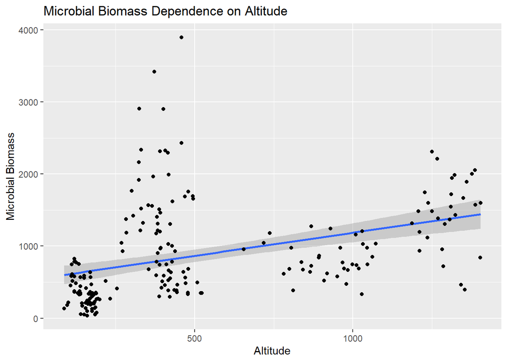

```r
ggplot(data = microbe, aes(x = altitude, y = microbial.biomass)) +
  geom_smooth(method = "lm") +
  geom_point() +
  labs(x = "Altitude",
       y = "Microbial Biomass",
       title = "Microbial Biomass Dependence on Altitude")
```

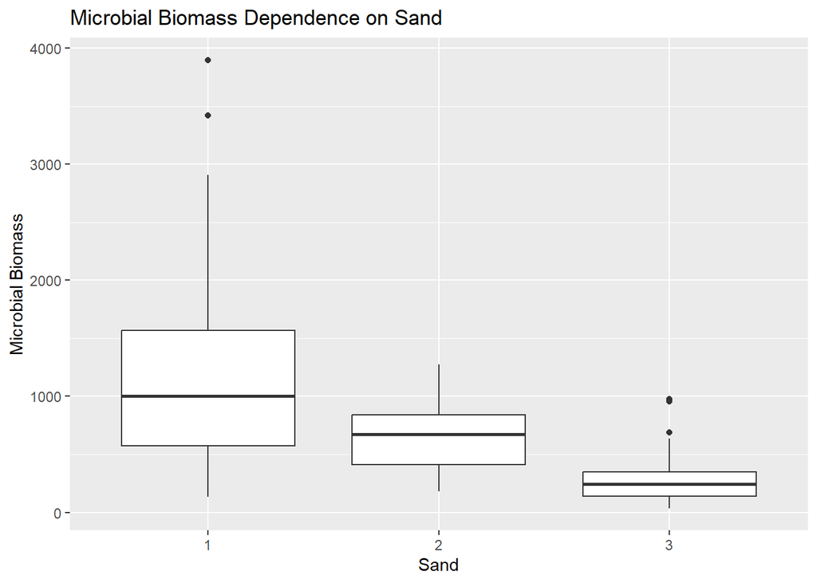

```r
ggplot(data = microbe, aes(x = sand, y = microbial.biomass)) +
  geom_boxplot() +
  labs(x = "Sand",
       y = "Microbial Biomass",
       title = "Microbial Biomass Dependence on Sand")
```

## Final question

What are your random effects and how did you incorporate them?

I have tried using country as random intercept (I deleted the output afterwards), which did not improve much of my model. I also tried using species composition, but the number is too small. A suggestion that I think can be done, but I did not do, is to manually categorise conifer proportion, into meaningful groups, or forest type like “conifer”, “semi-conifer”, “non-conifer” then, use it as random effects, with interaction with species richness.